# Modeling Inbound Tourism

### Using weihted average by Contries

```python
#Variables using the data aviable Model 1
XWA=MultilinearDataAvgW[['Distance','Cultural','Government_prioritization','Segurity_homocide','Segurity_terrorism','Natural_resources','Price_competitiveness','Service_infrastructure','Visa_requirements']]
yWA=MultilinearDataAvgW['Inbound Visitors']
#Variables using distance and lienar regression significant Model 2
X2WA=MultilinearDataAvgW[['Distance','Cultural','Natural_resources','Service_infrastructure']]
y2WA=MultilinearDataAvgW['Inbound Visitors']
#Variables using lienar regression significant Model 3
X3WA=MultilinearDataAvgW[['Cultural','Natural_resources','Service_infrastructure']]
y3WA=MultilinearDataAvgW['Inbound Visitors']

#Variables using lienar regression significant Model 4
X4WA=MultilinearDataAvgW[['Cultural','Natural_resources']]
y4WA=MultilinearDataAvgW['Inbound Visitors']

#To train and test Model 1
XTrainWA, XTestWA, yTrainWA, yTestWA=train_test_split(XWA,yWA, random_state=0)

#To train and test Model 2
X2TrainWA, X2TestWA, y2TrainWA, y2TestWA=train_test_split(X2WA,y2WA, random_state=0)

#To train and test Model 3
X3TrainWA, X3TestWA, y3TrainWA, y3TestWA=train_test_split(X3WA,y3WA, random_state=0)

#To train and test Model 4
X4TrainWA, X4TestWA, y4TrainWA, y4TestWA=train_test_split(X4WA,y4WA, random_state=0)
```

##### Results of Model 1

$Tourism $=$f$ ($distance$,$culture$,$GP$,$SH$,$ST$,$NR$,$PC$,$SI$,$VR$)

```python
ResultsModel(XTrainWA, XTestWA, yTrainWA, yTestWA,XWA)
```

|  | Variables | Coeficientes |
| --- | --- | --- |
| 0 | Distance | 0.001846 |
| 1 | Cultural | 210.825520 |
| 2 | Government_prioritization | -446.202834 |
| 3 | Segurity_homocide | -1537.244543 |
| 4 | Segurity_terrorism | -502.590893 |
| 5 | Natural_resources | 59.351419 |
| 6 | Price_competitiveness | -795.085311 |
| 7 | Service_infrastructure | 41.734757 |
| 8 | Visa_requirements | -796.298580 |
| 9 | Intercept | 11021.583304 |

```
0.053
```

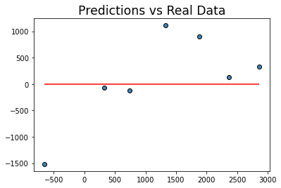

```
(None, None)
```

```python
graphModelResults(XTrainWA, XTestWA, yTrainWA, yTestWA)
```

##### Results of Model 2

$Tourism $=$f$ ($distance$,$culture$,$NR$,$SI$)

```python
ResultsModel(X2TrainWA, X2TestWA, y2TrainWA, y2TestWA,X2WA)
```

|  | Variables | Coeficientes |
| --- | --- | --- |
| 0 | Distance | 0.057280 |
| 1 | Cultural | 455.809469 |
| 2 | Natural_resources | -417.199165 |
| 3 | Service_infrastructure | 139.351530 |
| 4 | Intercept | 536.287978 |

```
0.51
```

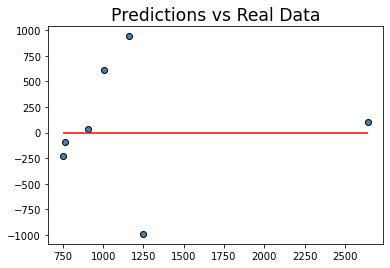

```
(None, None)
```

```python
graphModelResults(X2TrainWA, X2TestWA, y2TrainWA, y2TestWA)
```

##### Results of Model 3

$Tourism $=$f$ ($culture$,$NR$,$SI$)

```python
ResultsModel(X3TrainWA, X3TestWA, y3TrainWA, y3TestWA,X3WA)
```

|  | Variables | Coeficientes |
| --- | --- | --- |
| 0 | Cultural | 449.721522 |
| 1 | Natural_resources | -235.282792 |
| 2 | Service_infrastructure | 83.914922 |
| 3 | Intercept | 367.645161 |

```
0.554
```

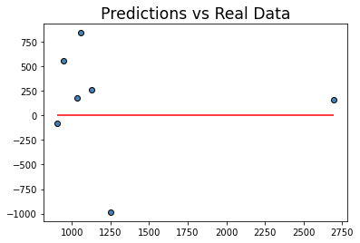

```
(None, None)
```

```python
graphModelResults(X3TrainWA, X3TestWA, y3TrainWA, y3TestWA)
```

##### Results of Model 4

$Tourism $=$f$ ($culture$,$NR$)

```python
ResultsModel(X4TrainWA, X4TestWA, y4TrainWA, y4TestWA,X4WA)
```

|  | Variables | Coeficientes |
| --- | --- | --- |
| 0 | Cultural | 454.170096 |
| 1 | Natural_resources | -194.855607 |
| 2 | Intercept | 663.715443 |

```
0.495
```

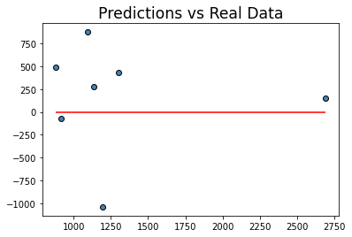

```
(None, None)
```

```python
graphModelResults(X4TrainWA, X4TestWA, y4TrainWA, y4TestWA)
```

## Using Panel Data Analysis

We used panel data because we have diferents countries at several point of time (years). We used differents, however we on¡bserved that the best estimations of panel data is:

- Pooled OLS Estimation

Similar in section above we used differents models to predic data

##### Model 1

$Tourism $=$f$ ($distance$,$culture$,$GP$,$SH$,$ST$,$NR$,$PC$,$SI$,$VR$)

##### Model 2

$Tourism $=$f$ ($distance$,$culture$,$NR$,$SI$)

##### Model 3

$Tourism $=$f$ ($culture$,$NR$,$SI$)

##### Model 4

$Tourism $=$f$ ($culture$,$NR$)

where

$distance$= Indicate how far are two contries by kilometers

$culture$= The index of cultural resources and business 7 indicate more offer of cultural resources while 1 indicate less offer of cultural resources

$GP$= The index Government prioritization of the travel & tourism industry 7 indicate top priority while 1 indicate no priority at all

$SH$= The index Homicide rate 7 less number of homocide per 100,000 population while 1 less number of homocide per 100,000 population

$ST$= The Index of terrorism incidence 7 indicate no attack while 1 most attacks or casualities

$NR$= Natural Resources 7 indicate more offer of natural resources while 1 indicate less offer

$PC$= Price competitiveness 7 indicate more price competitiviness while 1 less price competitiviness

$SI$= The transport infraestructura 7 indicate more developet infraestructure while 1 less develop infraestructure

$VR$= Visa requirements two countries 7 less requirements while 1 more requirements

```python
DataforPD=tourismData.set_index(['Country','Year'])
```

```python
def GraphPD(Y_Predict, Y_TestPD):
    predict=Y_Predict
    real=Y_TestPD
    predictY=predict.reset_index()
    realY=real.reset_index()



    x=predictY['predictions']
    Ry=realY['Inbound Visitors']
    y=(x-Ry)
    plt.scatter(x,y, color='black', marker='o', facecolor='steelblue')
    plt.title(f'Predictions vs Real Data', fontsize='xx-large')
    plt.hlines(y=0, xmin=x.min(), xmax=x.max(), color='red')


    return plt.show()
```

```python
##Variables using the data aviable Model 1
XPD=DataforPD[['Distance','Cultural','Government_prioritization','Segurity_homocide','Segurity_terrorism','Natural_resources','Price_competitiveness','Service_infrastructure','Visa_requirements']]
yPD=DataforPD['Inbound Visitors']
#Variables using distance and lienar regression significant Model 2
X2PD=DataforPD[['Distance','Cultural','Natural_resources','Service_infrastructure']]
y2PD=DataforPD['Inbound Visitors']
#Variables using lienar regression significant Model 3
X3PD=DataforPD[['Cultural','Natural_resources','Service_infrastructure']]
y3PD=DataforPD['Inbound Visitors']

#Variables using lienar regression significant Model 4
X4PD=DataforPD[['Cultural','Natural_resources']]
y4PD=DataforPD['Inbound Visitors']

#To train and test Model 1
XTrainPD, XTestPD, yTrainPD, yTestPD=train_test_split(XPD,yPD, random_state=0)

#To train and test Model 2
X2TrainPD, X2TestPD, y2TrainPD, y2TestPD=train_test_split(X2PD,y2PD, random_state=0)

#To train and test Model 3
X3TrainPD, X3TestPD, y3TrainPD, y3TestPD=train_test_split(X3PD,y3PD, random_state=0)

#To train and test Model 4
X4TrainPD, X4TestPD, y4TrainPD, y4TestPD=train_test_split(X4PD,y4PD, random_state=0)
```

```python
#To train and test Model 1
modPD1 = PooledOLS(yTrainPD, XTrainPD)
PoolPD1_res = modPD1.fit()
predictY1=PoolPD1_res.predict(XTestPD)
#To train and test Model 2
modPD2 = PooledOLS(y2TrainPD, X2TrainPD)
PoolPD2_res = modPD2.fit()
predictY2=PoolPD2_res.predict(X2TestPD)

#To train and test Model 3
modPD3 = PooledOLS(y3TrainPD, X3TrainPD)
PoolPD3_res = modPD3.fit()
predictY3=PoolPD3_res.predict(X3TestPD)

#To train and test Model 4
modPD4 = PooledOLS(y4TrainPD, X4TrainPD)
PoolPD4_res = modPD4.fit()
predictY4=PoolPD4_res.predict(X4TestPD)
```

##### Results of Model 1

$Tourism $=$f$ ($distance$,$culture$,$GP$,$SH$,$ST$,$NR$,$PC$,$SI$,$VR$)

```python
print(PoolPD1_res)
```

```
                          PooledOLS Estimation Summary
================================================================================
Dep. Variable:       Inbound Visitors   R-squared:                        0.7436
Estimator:                  PooledOLS   R-squared (Between):              0.8913
No. Observations:                 385   R-squared (Within):              -0.0747
Date:                Wed, Mar 17 2021   R-squared (Overall):              0.7436
Time:                        14:13:46   Log-likelihood                   -3066.7
Cov. Estimator:            Unadjusted
                                        F-statistic:                      121.19
Entities:                          25   P-value                           0.0000
Avg Obs:                       15.400   Distribution:                   F(9,376)
Min Obs:                       6.0000
Max Obs:                       22.000   F-statistic (robust):             121.19
                                        P-value                           0.0000
Time periods:                       5   Distribution:                   F(9,376)
Avg Obs:                       77.000
Min Obs:                       75.000
Max Obs:                       81.000

                                     Parameter Estimates
=============================================================================================
                           Parameter  Std. Err.     T-stat    P-value    Lower CI    Upper CI
---------------------------------------------------------------------------------------------
Distance                      0.0093     0.0075     1.2508     0.2118     -0.0053      0.0240
Cultural                      329.88     31.502     10.472     0.0000      267.94      391.83
Government_prioritization    -219.83     65.550    -3.3536     0.0009     -348.72     -90.940
Segurity_homocide             188.33     139.40     1.3510     0.1775     -85.778      462.44
Segurity_terrorism           -150.26     31.985    -4.6977     0.0000     -213.15     -87.364
Natural_resources            -125.15     60.978    -2.0523     0.0408     -245.05     -5.2443
Price_competitiveness         13.449     46.437     0.2896     0.7723     -77.860      104.76
Service_infrastructure        519.52     86.081     6.0353     0.0000      350.26      688.78
Visa_requirements            -231.74     62.339    -3.7173     0.0002     -354.31     -109.16
=============================================================================================
```

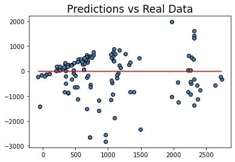

```python
GraphPD(predictY1, yTestPD)
```

##### Results of Model 2

$Tourism $=$f$ ($distance$,$culture$,$NR$,$SI$)

```python
print(PoolPD2_res)
```

```
                          PooledOLS Estimation Summary
================================================================================
Dep. Variable:       Inbound Visitors   R-squared:                        0.7002
Estimator:                  PooledOLS   R-squared (Between):              0.8413
No. Observations:                 385   R-squared (Within):              -0.0413
Date:                Wed, Mar 17 2021   R-squared (Overall):              0.7002
Time:                        14:13:46   Log-likelihood                   -3096.8
Cov. Estimator:            Unadjusted
                                        F-statistic:                      222.48
Entities:                          25   P-value                           0.0000
Avg Obs:                       15.400   Distribution:                   F(4,381)
Min Obs:                       6.0000
Max Obs:                       22.000   F-statistic (robust):             222.48
                                        P-value                           0.0000
Time periods:                       5   Distribution:                   F(4,381)
Avg Obs:                       77.000
Min Obs:                       75.000
Max Obs:                       81.000

                                   Parameter Estimates
==========================================================================================
                        Parameter  Std. Err.     T-stat    P-value    Lower CI    Upper CI
------------------------------------------------------------------------------------------
Distance                   0.0135     0.0078     1.7179     0.0866     -0.0019      0.0289
Cultural                   423.00     30.477     13.880     0.0000      363.08      482.93
Natural_resources         -294.32     52.670    -5.5880     0.0000     -397.88     -190.76
Service_infrastructure     134.71     32.004     4.2093     0.0000      71.786      197.64
==========================================================================================
```

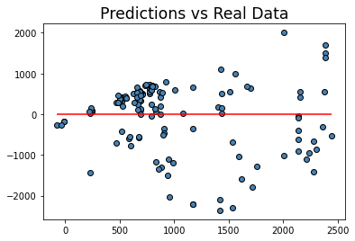

```python
GraphPD(predictY2, y2TestPD)
```

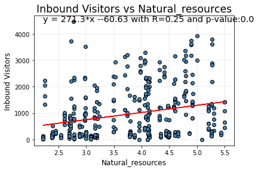

```python
graphRegressSimple(X2TrainPD['Natural_resources'],y2TrainPD)
```

##### Results of Model 3

$Tourism $=$f$ ($culture$,$NR$,$SI$)

```python
print(PoolPD3_res)
```

```
                          PooledOLS Estimation Summary
================================================================================
Dep. Variable:       Inbound Visitors   R-squared:                        0.6979
Estimator:                  PooledOLS   R-squared (Between):              0.8315
No. Observations:                 385   R-squared (Within):              -0.0086
Date:                Wed, Mar 17 2021   R-squared (Overall):              0.6979
Time:                        14:13:46   Log-likelihood                   -3098.3
Cov. Estimator:            Unadjusted
                                        F-statistic:                      294.16
Entities:                          25   P-value                           0.0000
Avg Obs:                       15.400   Distribution:                   F(3,382)
Min Obs:                       6.0000
Max Obs:                       22.000   F-statistic (robust):             294.16
                                        P-value                           0.0000
Time periods:                       5   Distribution:                   F(3,382)
Avg Obs:                       77.000
Min Obs:                       75.000
Max Obs:                       81.000

                                   Parameter Estimates
==========================================================================================
                        Parameter  Std. Err.     T-stat    P-value    Lower CI    Upper CI
------------------------------------------------------------------------------------------
Cultural                   421.89     30.547     13.811     0.0000      361.83      481.95
Natural_resources         -271.66     51.122    -5.3140     0.0000     -372.18     -171.15
Service_infrastructure     128.23     31.862     4.0246     0.0001      65.585      190.88
==========================================================================================
```

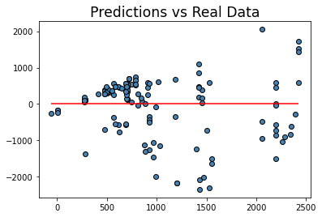

```python
GraphPD(predictY3, y3TestPD)
```

##### Results of Model 4

$Tourism $=$f$ ($culture$,$NR$)

```python
print(PoolPD4_res)
```

```
                          PooledOLS Estimation Summary
================================================================================
Dep. Variable:       Inbound Visitors   R-squared:                        0.6851
Estimator:                  PooledOLS   R-squared (Between):              0.8219
No. Observations:                 385   R-squared (Within):              -0.0015
Date:                Wed, Mar 17 2021   R-squared (Overall):              0.6851
Time:                        14:13:46   Log-likelihood                   -3106.3
Cov. Estimator:            Unadjusted
                                        F-statistic:                      416.61
Entities:                          25   P-value                           0.0000
Avg Obs:                       15.400   Distribution:                   F(2,383)
Min Obs:                       6.0000
Max Obs:                       22.000   F-statistic (robust):             416.61
                                        P-value                           0.0000
Time periods:                       5   Distribution:                   F(2,383)
Avg Obs:                       77.000
Min Obs:                       75.000
Max Obs:                       81.000

                                 Parameter Estimates
=====================================================================================
                   Parameter  Std. Err.     T-stat    P-value    Lower CI    Upper CI
-------------------------------------------------------------------------------------
Cultural              425.17     31.136     13.655     0.0000      363.95      486.39
Natural_resources    -97.630     27.805    -3.5113     0.0005     -152.30     -42.961
=====================================================================================
```

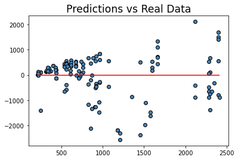

```python
GraphPD(predictY4, y4TestPD)
```

```python
tourismData.to_csv(path_or_buf=os.path.join('..','..','output','DataSetAll.csv'), sep=',', index=False)
LinearModelCoef=ResultsModel(XTrain, XTest, yTrain, yTest,X) #Resoults of 35
LinearModelWACoef=ResultsModel(XTrainWA, XTestWA, yTrainWA, yTestWA,XWA) #Resoults of 35
LinearModelCoef.to_csv(path_or_buf=os.path.join('..','..','output','Coef_linearModel.csv'), sep=',', index=False)
LinearModelWACoef.to_csv(path_or_buf=os.path.join('..','..','output','Coef_linearModelWeigthAve.csv'), sep=',', index=False)
```